🏠 Inicio del curso | 📊 Volatilidad histórica y EWMA

# Estimación de volatilidad histórica y EWMA — AMZN

Andrés Londoño

Guía de qué hace cada bloque y qué se ve en cada gráfico, en el mismo orden del script de clase. Precio de cierre ajustado diario de **Amazon (AMZN)**, 2024-01-02 a 2026-08-28 (666 retornos diarios).

```r
if (!require("pacman")) install.packages("pacman")
pacman::p_load(tidyverse, xts, tseries, magrittr, ggpubr, zoo, forecast,
               quantmod, MTS, zoo, FinTS, lmtest, scales, timetk, readxl, psych)

# 1. Definicion automatica de la ruta de trabajo ----
if (!require("rstudioapi")) install.packages("rstudioapi")
tryCatch(setwd(dirname(rstudioapi::getActiveDocumentContext()$path)), error = function(e) NULL)
```

```r
options(scipen = 999)
```

## 1. Descarga de precios y cálculo de retornos diarios

```r
# 2. Consulta de precios y calculo de retornos diarios ----

acciones <- c("AMZN")

precio <- quantmod::getSymbols(acciones, src = "yahoo",
                                      from = "2023-12-31",
                                      to = "2026-08-31",
                                      periodicity = "daily",
                                      auto.assign = TRUE,
                                      warnings = FALSE) %>%
  purrr::map(~quantmod::Ad(get(.))) %>%
  purrr::reduce(merge.xts) %>%
  `colnames<-`(acciones)
```

**`TTR::ROC()` con `na.pad = FALSE` — bug real encontrado y corregido.** El script original usaba `na.pad = F` para no dejar el primer valor en NA. Al verificarlo a mano (comparando contra `diff(log(precio))`), esa combinación específica de `TTR::ROC()` en esta versión del paquete **calcula mal el retorno para todas las observaciones** — no solo recorta el NA, corrompe el cálculo completo (el primer retorno salía en +500% en vez de -0.98%, y arrastraba el resto). La solución correcta es dejar `na.pad = TRUE` (el default, que sí calcula bien) y quitar el NA después con `na.omit()` — el resultado final (sin la primera fila) es el mismo que se buscaba, pero con los números correctos.

```r
retornos <- TTR::ROC(precio,
                     type = "continuous",
                     na.pad = TRUE) %>%
  na.omit()
```

## 1.1 Gráfico de los retornos diarios

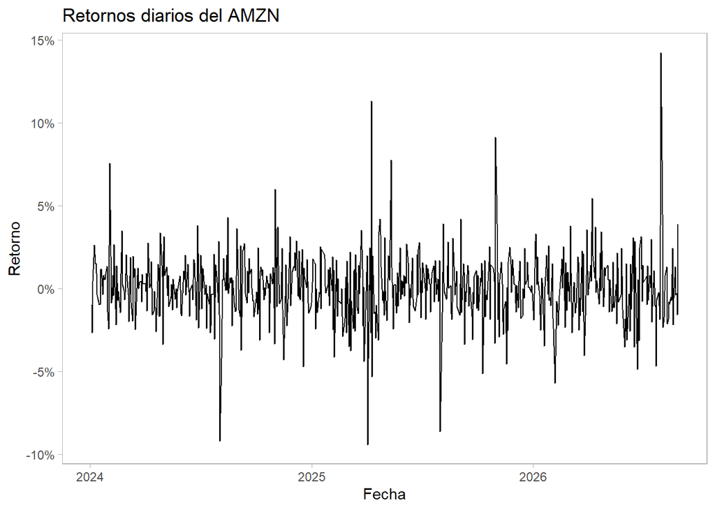

```r
## 2.1. Grafico de los retornos diarios ----

p.retornos <- forecast::autoplot(retornos)+
    labs(title = paste("Retornos diarios del AMZN"),
       x = "Fecha",
       y = "Retorno") +
    scale_y_continuous(labels = label_percent()) +
    theme_light() +
    theme(panel.grid = element_blank())
p.retornos
```

**Interpretación**: los retornos oscilan alrededor de cero, sin tendencia — la firma típica de una serie ya estacionaria (a diferencia del precio, que sube de USD 149.93 a USD 266.43 en el período). Se ven rachas de mayor y menor volatilidad (clusters) — el mismo hecho estilizado de los retornos financieros que motiva EWMA/GARCH más adelante, en vez de asumir volatilidad constante.

## 1.2 Estadísticas descriptivas de los retornos

```r
## 2.2. Estadisticas descriptivas de los retornos -------------------------------

describe(x = zoo::coredata(retornos),
         quant = c(0.025, 0.25, 0.75, 0.975),
         trim = 0,
         fast = F) %>%
  t() %>%
  round(digits = 4)
```

```
##                X1
## vars       1.0000
## n        666.0000
## mean       0.0009
## sd         0.0204
## median     0.0006
## trimmed    0.0009
## mad        0.0169
## min       -0.0941
## max        0.1425
## range      0.2366
## skew       0.5196
## kurtosis   6.6194
## se         0.0008
## Q0.025    -0.0385
## Q0.25     -0.0102
## Q0.75      0.0127
## Q0.975     0.0376
```

**Interpretación**: media diaria ≈0.09% (positiva, consistente con la tendencia alcista del precio en el período), desviación estándar diaria ≈2.04% (una acción individual, más volátil que un índice amplio). El mínimo (-9.41%, el 2025-04-03) y el máximo (+14.25%, el 2026-07-31) no son simétricos — la asimetría (*skew*≈0.52, positiva) y el **exceso de curtosis** (≈6.62, que es lo que reporta `psych::describe`; equivale a una curtosis ≈9.62, frente a 0 de la normal si se mide en exceso, o frente a 3 si se mide la curtosis total) confirman el mismo hecho estilizado de colas pesadas que ya vimos en el módulo de ARIMA: la distribución real de retornos no es normal.

## 1.3 Histograma de los retornos vs. distribución normal

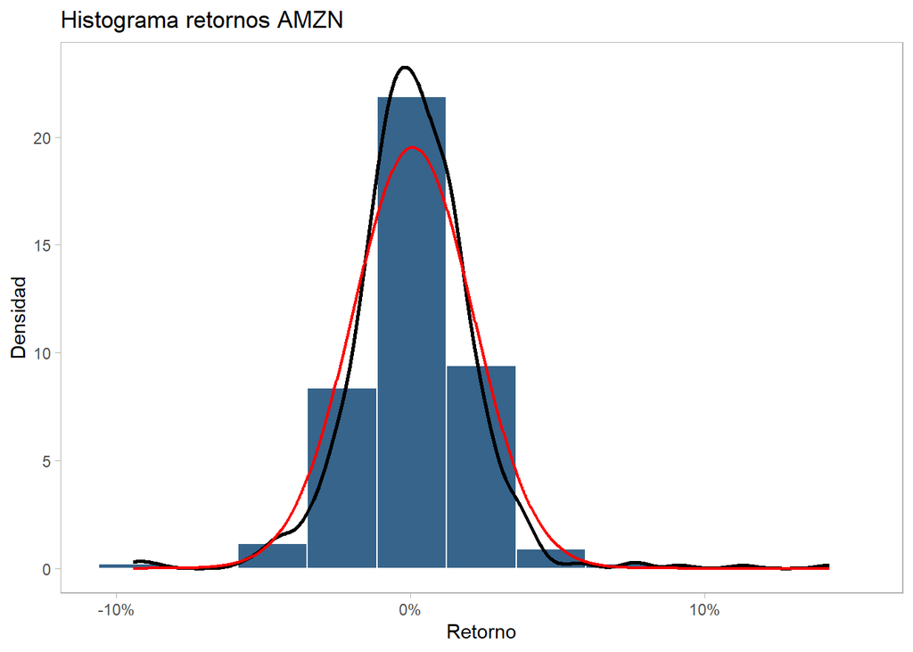

```r
## 2.3. Histograma de los retornos ----------------------------------------------

dens <- ggplot(data = retornos,
               mapping = aes(x = AMZN)) +
  geom_histogram(aes(y = after_stat(density)),
                 fill = "steelblue4",
                 color = "white",
                 bins = nclass.Sturges(x = retornos$AMZN),
                 closed = "right") +
  geom_density(linewidth = 1) +
  stat_function(fun = dnorm,
                n=1001,
                args = list(mean = mean(retornos$AMZN), sd = sd(retornos$AMZN)),
                color = "red",
                linewidth = 0.75) +
    scale_x_continuous(labels = label_percent()) +
  theme_light() +
  labs(title = paste("Histograma retornos AMZN"),
       x = "Retorno",
       y = "Densidad") +
    theme(panel.grid = element_blank())
dens
```

**Interpretación**: la curva negra (densidad real, suavizada) es más alta y angosta en el centro que la curva roja (normal teórica con la misma media/varianza), y tiene colas más largas — justo lo que anticipaba el exceso de curtosis alto de la tabla anterior. Confirma visualmente por qué no conviene asumir normalidad al calcular medidas de riesgo (VaR, por ejemplo) sobre estos retornos.

## 2. Volatilidad histórica (ventana expansiva)

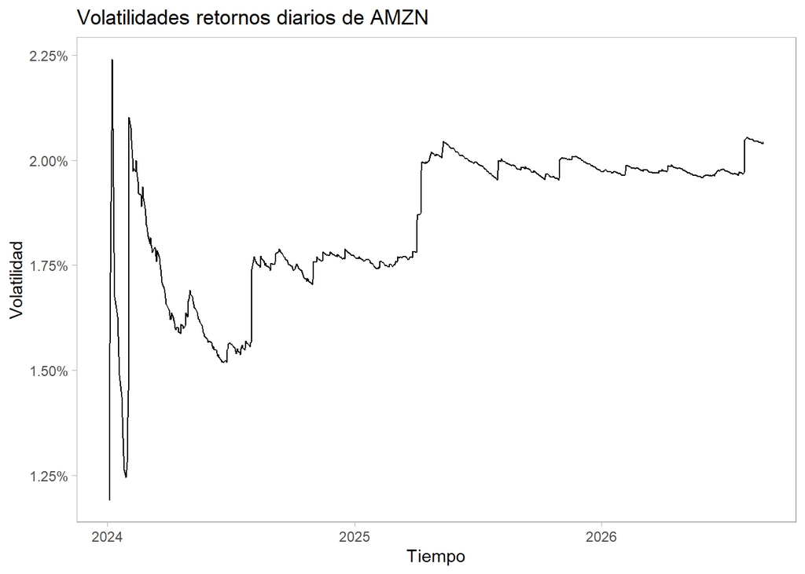

```r
# 3. Volatilidad histórica ---------------------------------------------------

n <- nrow(retornos)
Vol_Historica <- vector()
for(i in 2:n){
  Vol_Historica[i-1] = sd(retornos[1:i])
  }
Vol_Historica <- xts(x = Vol_Historica,
                     order.by = index(retornos$AMZN)[-1])

p.VolHist <- forecast::autoplot(Vol_Historica) +
  labs(title = paste("Volatilidades retornos diarios de AMZN"),
       x = "Tiempo",
       y = "Volatilidad") +
    scale_y_continuous(labels = label_percent()) +
  theme_light() +
    theme(panel.grid = element_blank())
p.VolHist
```

**Interpretación**: en cada punto del tiempo se calcula la desviación estándar usando **todos** los datos desde el inicio hasta ese momento (ventana que crece, nunca se “olvida” del pasado). Por eso la línea se ve cada vez más plana/estable hacia el final — con más datos acumulados, un solo día extremo pesa cada vez menos en el promedio. Es la forma más simple de estimar volatilidad, pero reacciona muy lento a cambios recientes del mercado — justo la limitación que EWMA (sección 3) viene a resolver.

## 2.1 Volatilidad histórica vía retornos al cuadrado

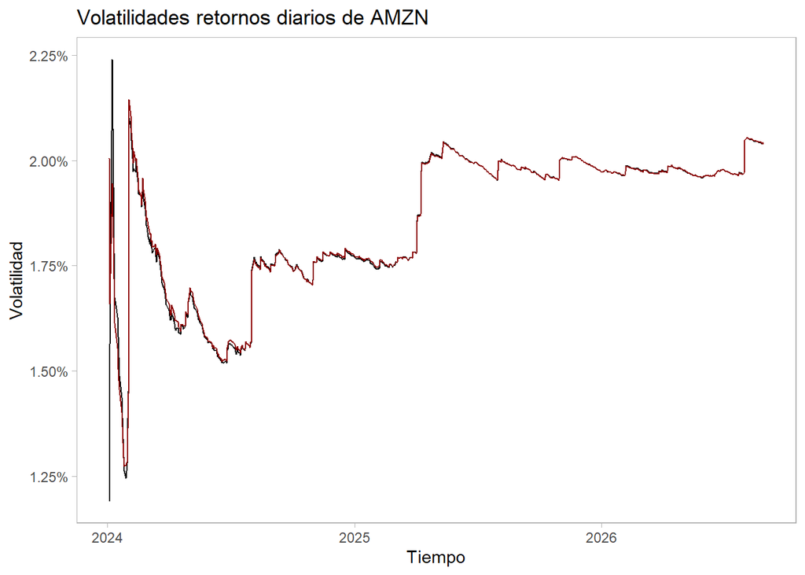

```r
## 3.1. Calculo volatilidad historica retornos al cuadrado ----------------------

retornos2 <- retornos^2

n <- nrow(retornos2)
Vol_Historica_R2 <- vector()
for(i in 2:n){
  Vol_Historica_R2[i-1] = mean(retornos2[1:i])
  }
Vol_Historica_R2 <- xts(x = sqrt(Vol_Historica_R2),
                        order.by = index(retornos$AMZN)[-1])

p.VolHistR2 <- p.VolHist +
  geom_line(aes(x =index(Vol_Historica_R2),
                y = Vol_Historica_R2), color = "darkred")
p.VolHistR2
```

**Interpretación**: la línea roja (raíz del promedio expansivo de retornos²) es matemáticamente casi idéntica a la sd tradicional cuando la media de los retornos es cercana a cero (que es el caso aquí, ≈0.09% diario) — por eso las dos líneas prácticamente se superponen. Es una forma alternativa de llegar al mismo resultado, útil como base conceptual directa para EWMA (que pondera esos mismos retornos² con más peso a lo reciente, en vez de pesarlos todos igual).

## 2.2 Volatilidad con ventana móvil (rolling window)

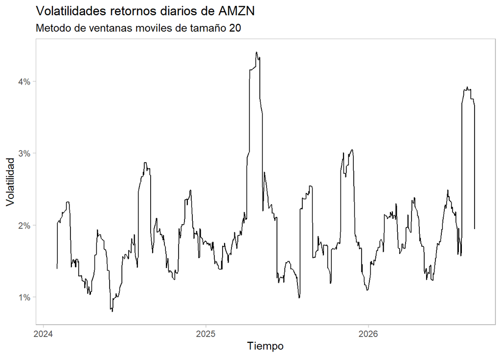

```r
## 3.2. Calculo de la volatilidad con ventanas moviles ---------------------------

ventana <- 20

desvest_movil <- zoo::rollapply(data = retornos,
                                width = ventana,
                                FUN = sd) %>%
  na.omit()

p.desvest_movil <- forecast::autoplot(desvest_movil) +
  labs(title = paste("Volatilidades retornos diarios de AMZN"),
       subtitle = paste("Metodo de ventanas moviles de tamaño", ventana),
       x = "Tiempo",
       y = "Volatilidad") +
    scale_y_continuous(labels = label_percent()) +
  theme_light() +
    theme(panel.grid = element_blank())
p.desvest_movil
```

**Interpretación**: a diferencia de la ventana expansiva (que nunca “olvida” nada), acá solo se usan los últimos 20 días hábiles (~1 mes de trading) para cada punto — por eso esta línea es mucho más variable, con picos y valles claros que sí reaccionan a episodios recientes de estrés o calma del mercado. El costo: pierde por completo la memoria de eventos de hace más de 20 días, sin importar qué tan importantes fueron.

## 2.3 Retornos mensuales desplazados

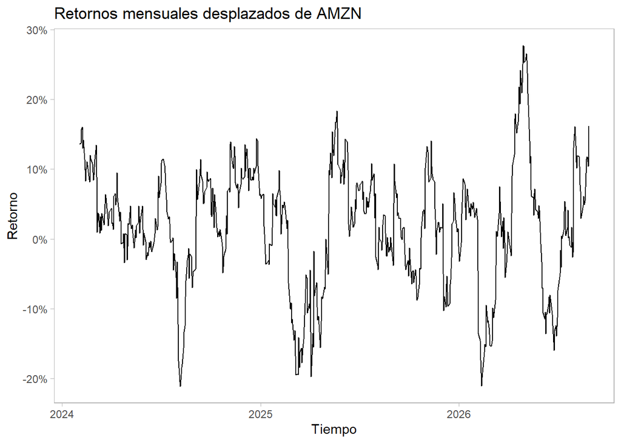

```r
## 3.3. Calculo de retornos mensuales desplazados ----

retornos.m <- TTR::ROC(x = precio, n = 22, type = "continuous") %>%
  na.omit()

p.retornos.m<- forecast::autoplot(retornos.m) +
  labs(title = paste("Retornos mensuales desplazados de AMZN"),
       x = "Tiempo",
       y = "Retorno") +
    scale_y_continuous(labels = label_percent()) +
  theme_light() +
    theme(panel.grid = element_blank())
p.retornos.m
```

**Interpretación**: son retornos acumulados de ~22 días hábiles (un mes de trading), calculados día a día (desplazados, no solo al cierre de cada mes calendario) — por eso hay uno por cada día del período, no solo 12 al año. Se ven oscilaciones mucho más amplias que en los retornos diarios (normal: acumular 22 días de movimiento amplifica tanto las subidas como las caídas).

## 2.4 Volatilidad histórica de los retornos mensuales

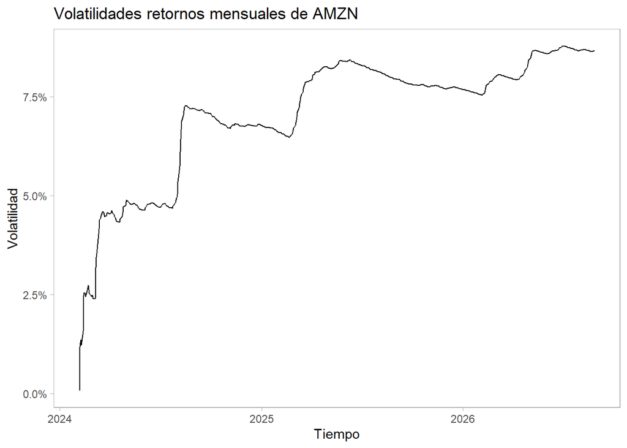

```r
## 3.4. Volatilidad histórica de los retornos mensuales -------------------------

n <- nrow(retornos.m)
Vol_Historica_M <- vector()
for(i in 2:n){
  Vol_Historica_M[i-1]=sd(retornos.m[1:i])
  }
Vol_Historica_M <- xts(x = Vol_Historica_M,
                       order.by = index(retornos.m$AMZN)[-1])

p.VolHist_M <- forecast::autoplot(Vol_Historica_M) +
  labs(title = paste("Volatilidades retornos mensuales de AMZN"),
       x = "Tiempo",
       y = "Volatilidad") +
    scale_y_continuous(labels = label_percent()) +
  theme_light() +
    theme(panel.grid = element_blank())
p.VolHist_M
```

**Interpretación**: mismo método de ventana expansiva de la sección 2, mismo comportamiento (cada vez más plana con el tiempo) — pero sobre los retornos mensuales, que son inherentemente más grandes en magnitud que los diarios, por eso la escala del eje Y es mucho mayor.

## 2.5 Volatilidad histórica de retornos mensuales al cuadrado

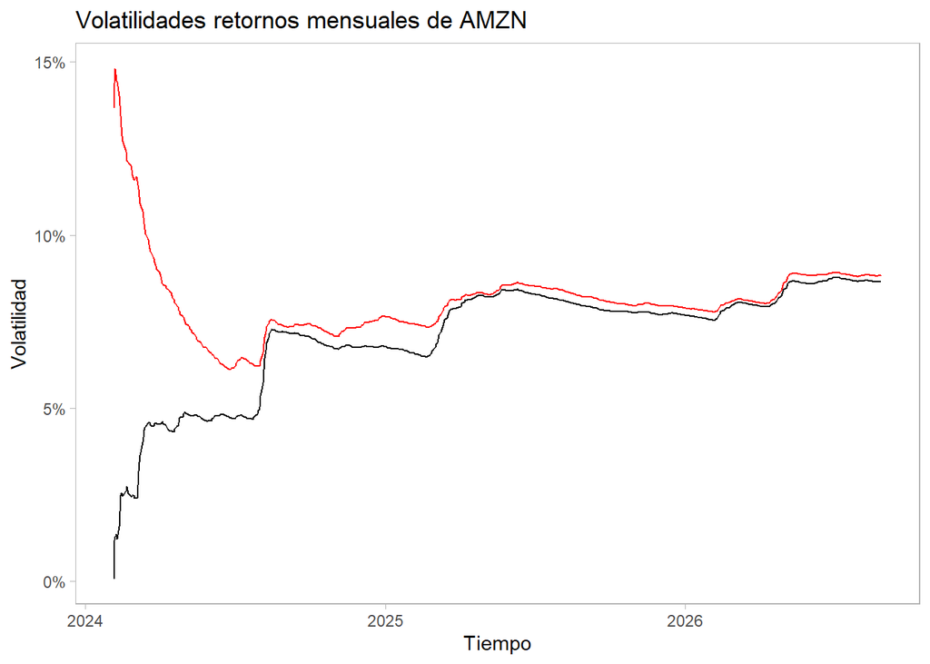

```r
## 3.5. Volatilidad historica retornos mensuales al cuadrado --------------------

retornos.m2 <- retornos.m^2
n <- nrow(retornos.m2)
Vol_Historica_R2_M <- vector()
for(i in 2:n){
  Vol_Historica_R2_M[i-1]=mean(retornos.m2[1:i])
  }
  Vol_Historica_R2_M <- xts(x = sqrt(Vol_Historica_R2_M), order.by = index(retornos.m$AMZN)[-1])

p.VolHistR2_M <- p.VolHist_M +
  geom_line(aes(x = index(Vol_Historica_R2_M),
                y = Vol_Historica_R2_M),
            color = "red")
p.VolHistR2_M
```

## 3. Volatilidad ponderada exponencial (EWMA)

A diferencia de los métodos anteriores (que pesan todos los días por igual, o los últimos N días por igual), EWMA le da **más peso a los días más recientes** — el peso decae exponencialmente hacia el pasado, según el parámetro λ (lambda). Con λ cercano a 1, casi no se olvida del pasado (parecido a la ventana expansiva); con λ chico, casi solo importa el día de ayer (muy reactivo, parecido a una ventana móvil muy corta).

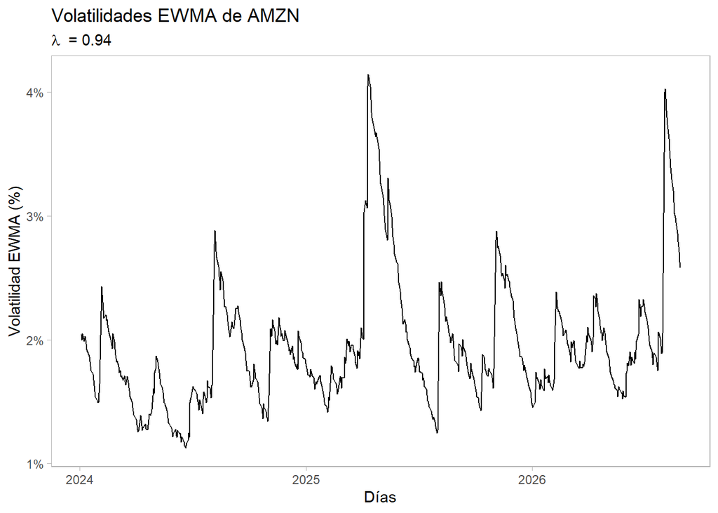

```r
# 4. Calculo de volatilidad ponderada exponencial (EWMA) ---------------------

## 4.1. lambda = 0.94 ----
EWMA_vol_0.94 <- MTS::EWMAvol(retornos, lambda = 0.94)
EWMA_vol_0.94_sigma <- xts(sqrt(EWMA_vol_0.94[["Sigma.t"]]), order.by = index(retornos))

p.EWMA.94 <- forecast::autoplot(EWMA_vol_0.94_sigma)+
  labs(title = paste("Volatilidades EWMA de AMZN"),
       subtitle = expression(lambda~" = 0.94"),
       x = "Días",
       y = "Volatilidad EWMA (%)") +
    scale_y_continuous(labels = label_percent()) +
  theme_light() +
    theme(panel.grid = element_blank())
p.EWMA.94
```

**Interpretación (λ=0.94)**: es el valor clásico que popularizó RiskMetrics (J.P. Morgan) para datos diarios — un balance entre reactividad y estabilidad. Se ve mucho más sensible a picos puntuales que la volatilidad expansiva (sección 2). Frente a la ventana móvil de 20 días (sección 2.2) la reactividad es comparable: la memoria efectiva de λ=0.94 es ≈1/(1−λ) ≈ 17 días, del mismo orden que una ventana de 20. La diferencia es de forma, no de suavidad: EWMA pondera con pesos que decaen exponencialmente, mientras que la ventana móvil pesa igual a los 20 días y luego descarta de golpe al día que sale.

## 3.1 EWMA con λ calculado a partir del tamaño de muestra

```r
## 4.2. lambda a partir de la cantidad de datos ----
lambda_datos <- 1-(2/(length(retornos)+1))
lambda_datos
```

```
## [1] 0.9970015
```

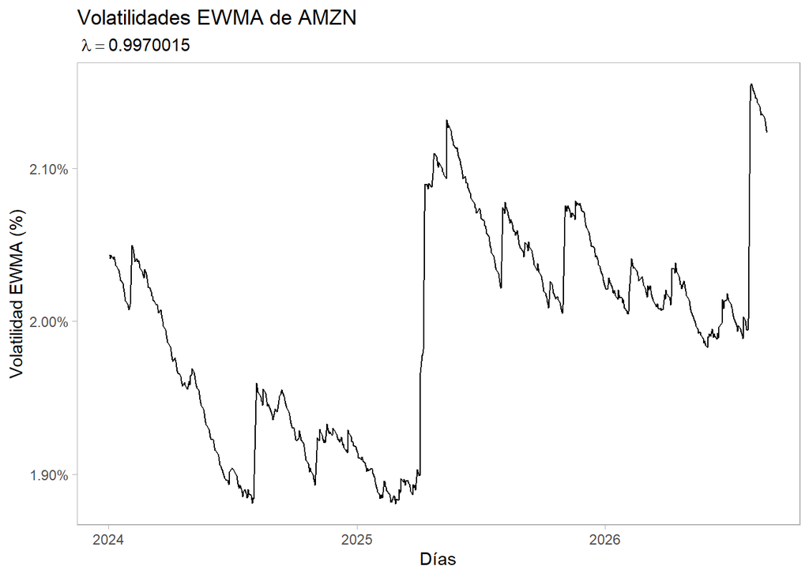

```r
EWMA_vol_0.99 <- MTS::EWMAvol(retornos, lambda = lambda_datos)
EWMA_vol_0.99_sigma <- xts(x = sqrt(EWMA_vol_0.99[["Sigma.t"]]), order.by = index(retornos))

p.EWMA.99 <- forecast::autoplot(EWMA_vol_0.99_sigma)+
  labs(title = paste("Volatilidades EWMA de AMZN"),
       subtitle = bquote(~lambda == .(lambda_datos)),
       x = "Días",
       y = "Volatilidad EWMA (%)") +
    scale_y_continuous(labels = label_percent()) +
  theme_light() +
    theme(panel.grid = element_blank())
p.EWMA.99
```

## 3.2 EWMA con λ = 0.5 (muy reactivo)

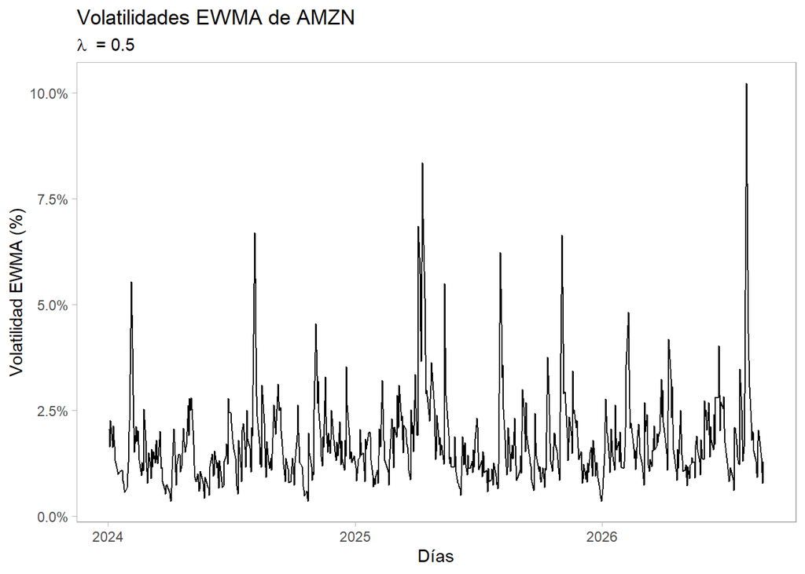

```r
## 4.3. lambda = 0.5 ----
EWMA_vol_0.5 <- MTS::EWMAvol(retornos, lambda = 0.5)
EWMA_vol_0.5_sigma <- xts(x = sqrt(EWMA_vol_0.5[["Sigma.t"]]), order.by = index(retornos))

p.EWMA.50 <- forecast::autoplot(EWMA_vol_0.5_sigma)+
  labs(title = paste("Volatilidades EWMA de AMZN"),
       subtitle = expression(lambda~" = 0.5"),
       x = "Días",
       y = "Volatilidad EWMA (%)") +
    scale_y_continuous(labels = label_percent()) +
  theme_light() +
    theme(panel.grid = element_blank())
p.EWMA.50
```

**Interpretación (λ=0.5)**: con un λ tan chico, casi todo el peso cae en los rezagos más recientes — el resultado es una volatilidad muy “nerviosa”, que sube y baja de golpe con cada shock puntual, sin suavizar casi nada. Es el extremo opuesto de λ≈0.997: mucha reactividad, poca estabilidad.

## Conclusión — comparando los 3 λ de EWMA

| λ | Comportamiento | Memoria del pasado |
| --- | --- | --- |
| 0.997 (de los datos) | Muy suave, casi no reacciona a shocks puntuales | Muy larga |
| 0.94 (RiskMetrics) | Balance intermedio | Media |
| 0.5 | Muy reactivo, sigue cada shock de cerca | Muy corta |

No hay un λ “correcto” universal — la elección depende de qué tan rápido quieras que tu estimado de riesgo reaccione a noticias nuevas vs. qué tan estable quieras que sea de un día a otro.